# Module 3 Solutions

## Question 6

Produce a line graph of the annual number of incident cases of ischemic heart disease events from 2010-2020 based on the three datasets you used above.

**Show R code**

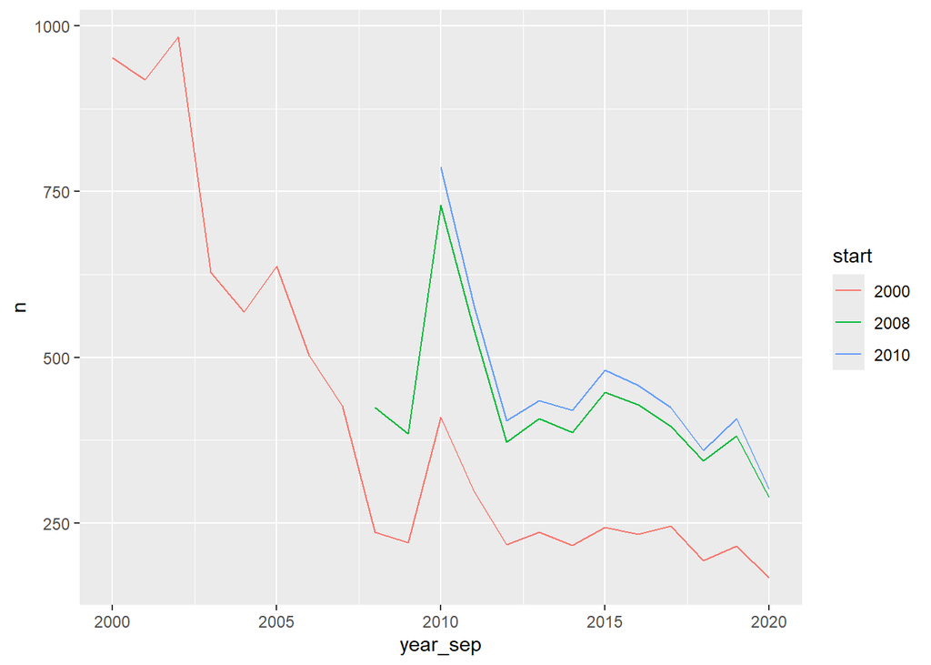

```r
## Basic line graph
plotdata <- bind_rows(
  ihd_year_table_2000 %>% mutate(start = "2000"), # make start year a character not a number, to force R to recognise it as categorical not continuous
  ihd_year_table_2008 %>% mutate(start = "2008"),
  ihd_year_table_2010 %>% mutate(start = "2010"))

## Quick plot to see trends
ggplot(data = plotdata) +
  geom_line(aes(x = year_sep, y = n, colour = start))
```

**Show R code**

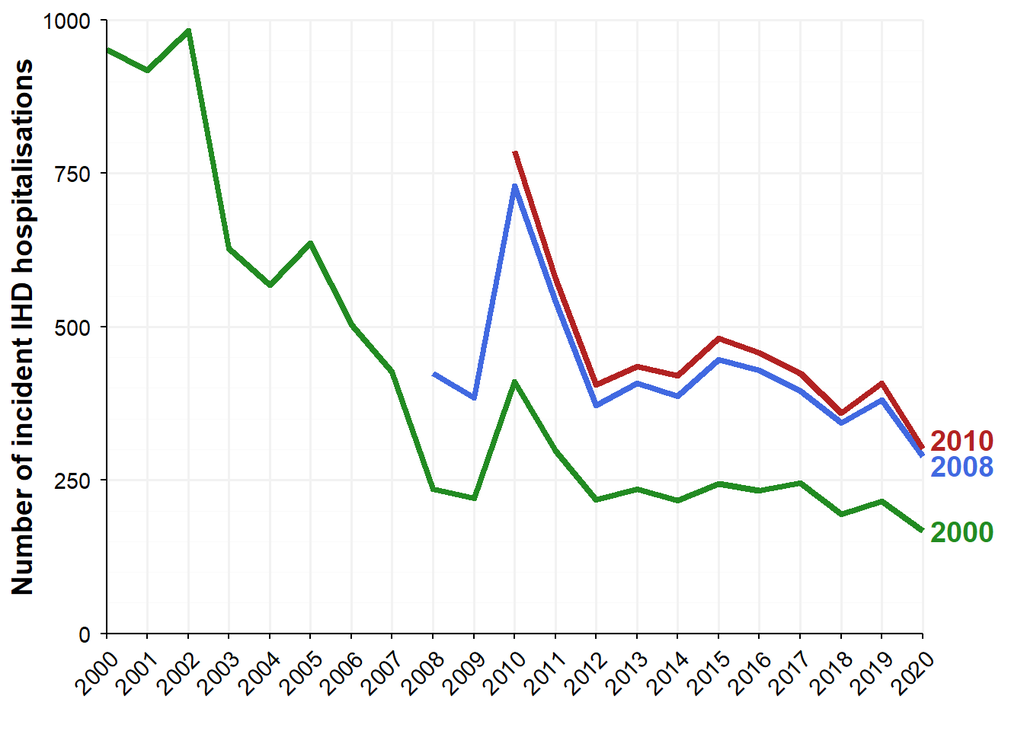

```r
## Nicer looking plot (if interested)
ggplot(data = plotdata, mapping = aes(x = year_sep, y = n)) +
  geom_line(aes(colour = start),
            linewidth = 1.5) +
  geom_text(data = plotdata %>% group_by(start) %>% slice(n()),
            aes(label = start, colour = start),
            size = 5, fontface = "bold", hjust = 0, nudge_x = 0.2, nudge_y = c(0, -15, 15)) +
  xlab("") +
  ylab("Number of incident IHD hospitalisations") +
  coord_cartesian(xlim = c(2000, 2020),
                  ylim = c(0, 1000),
                  clip = "off") +
  scale_x_continuous(breaks = 2000:2020,
                     minor_breaks = NULL,
                     expand = c(0, 0)) +
  scale_y_continuous(breaks = seq(0, 1000, 250),
                     minor_breaks = seq(0, 1000, 50),
                     expand = c(0, 0)) +
  scale_colour_manual(values = c("2000" = "forestgreen",
                                 "2008" = "royalblue",
                                 "2010" = "firebrick")) +
  theme_minimal() +
  theme(axis.text = element_text(colour = "black", size = 11),
        axis.title = element_text(colour = "black", size = 14, face = "bold"),
        axis.line = element_line(colour = "black"),
        axis.ticks = element_line(colour = "black"),
        axis.text.x = element_text(angle = 45, hjust = 1),
        legend.position = "none",
        panel.grid.major = element_line(colour = "grey95", linewidth = 0.7),
        panel.grid.minor = element_line(colour = "grey98", linewidth = 0.1),
        panel.border = element_blank(),
        plot.margin = margin(t = 10, b = 0, l = 5, r = 50))
```

1. What do you notice about the frequencies compared between the three datasets?  
   Frequencies are higher when starting the analysis in more recent years. This is because we are incorrectly counting IHD hospitalisations as incident IHD, when in fact there was a historical IHD hospitalisation earlier than the start of our analysis dataset.
2. Do you think a 4-year clearance period would be sufficient for obtaining an accurate estimate of incident cases in 2010? In the full analysis dataset (2000-2020), the number of incident IHD hospitalisations is initially high (due to the prevalent pool effect) but reaches a steady state after about 7-8 years. A 4-year clearance period would probably not be sufficient to accurately estimate incident IHD hospitalisations.

## PART TWO

For PUBH5215 students, the following coding can access the RDS version of the password-protected zip file.

````markdown
```{r}
# Set the folder directory based on operating system
rds <- ifelse(Sys.info()["sysname"]=="Windows", # Determine if using Windows or Mac
              "//shared.sydney.edu.au/research-data/PRJ-Linked_data_course", # Windows
              "/Volumes/PRJ-Linked_data_course") # Mac
exceldataloc <- file.path(rds, "Module 3")

#install.packages("archive")
library("archive")

#Import data using password
apdc_subset <- read.csv(archive::archive_read(file.path(exceldataloc, paste0("apdc_subset", ".zip")), "apdc_subset.csv", password = "mod3inR"))

```
````

For SHEED students (and for the purposes of this webpage to work), we can import and format the data directly from github as below.

**Show R code**

```r
# Import data from Github ----
## Read in csv file
apdc_subset <- read_csv("https://raw.githubusercontent.com/NicoleDeLaMata/LinkedData/refs/heads/main/apdc_subset.csv")

## Convert date variables to date format then sort the data
apdc_subset <- apdc_subset %>%
  mutate(episode_start_date = dmy(episode_start_date),
         episode_end_date = dmy(episode_end_date)) %>%
  arrange(ppn, episode_start_date, episode_end_date)

#Assign labels to mode of separation
table(apdc_subset$mode_of_separation_recode)
```

```
   0    1    2    4    5    7    8    9
   1 6514   53    1  418  106    3  108
```

**Show R code**

```r
apdc_subset$mode_of_separation_recode <- factor(apdc_subset$mode_of_separation_recode,
levels = c(0, 1, 2, 4, 5, 7, 8, 9),
labels = c("Discharge on leave", "Discharge by hospital", "Discharge at own risk", "Transfer to public psychiatric hospital", "Transfer to other hospital", "Death without autopsy", "Transfer to other accommodation", "Type change separation"))
```

## Question 7

Define how you would appropriately construct a study population with all the available hospitalisation data to determine length of stay for their kidney transplant admission. Consider what records should be included. What important assumptions have we made in constructing this study population?

**Steps for constructing the study population:**

1. Determine which episodes of care were part of the same hospital admission.

2. Flag any hospital admissions where any diagnosis code within any episode of care was related to kidney transplant

3. Remove episodes of care if there was no kidney transplant flagged for the entire hospital admission.

4. Calculate length of stay for each hospital admission (latest episode end date minus earliest episode start date).

5. Collapse the dataset to one row per person per kidney transplant hospital admission, keeping the length of stay for each admission.

**Assumptions:**

1. Hospital admissions are for kidney transplant even if the primary diagnosis code was unrelated.

2. We are assuming the entire length of stay was attributable to the kidney transplant, and not other medical issues that arose.

3. All transfers have been accounted for correctly, and there were no interstate transfers.

## Question 8

1. Looking at observations relating to ppn “Ue/R3tAbxDO” and year of separation = 2012. Which episodes of care have overlapping dates and how many total hospital admissions did this person have?

**Show R code**

```r
## Create a variable for year of separation
apdc_subset <- apdc_subset %>% mutate(year_sep = year(episode_end_date))

## Observations for ppn "Ue/R3tAbxDO" and year of separation 2012
apdc_subset %>%
  filter(ppn == "Ue/R3tAbxDO" & year_sep==2012) %>%
  select(ppn, episode_start_date, episode_end_date, mode_of_separation_recode) %>%
  print()
```

```
# A tibble: 5 × 4
  ppn         episode_start_date episode_end_date mode_of_separation_recode
  <chr>       <date>             <date>           <fct>
1 Ue/R3tAbxDO 2012-02-06         2012-02-06       Discharge by hospital
2 Ue/R3tAbxDO 2012-02-06         2012-02-24       Discharge by hospital
3 Ue/R3tAbxDO 2012-03-17         2012-03-17       Transfer to other hospital
4 Ue/R3tAbxDO 2012-03-17         2012-03-31       Discharge by hospital
5 Ue/R3tAbxDO 2012-10-14         2012-10-16       Discharge by hospital
```

PPN Ue/R3tAbxDO (2012) = 5 episodes, 4 admissions:

- #1 and #2 overlap (#1 end date is same as #2 start date). But they are two separate admissions. #1 is a single-day admission, #2 is an entirely new admission

- #3 and #4 overlap (#3 end date is same as #4 start date). #3 ends with a transfer, so these are both part of the same admission.

2. Looking at observations relating to ppn “7339/kP/Dy2” and year of separation = 2001. Which episodes of care have overlapping dates and how many total hospital admissions did this person have?

**Show R code**

```r
## Observations for ppn "7339/kP/Dy2" and year of separation 2001
apdc_subset %>%
  filter(ppn == "7339/kP/Dy2" & year_sep==2001) %>%
  select(ppn, episode_start_date, episode_end_date, mode_of_separation_recode) %>%
  print()
```

```
# A tibble: 5 × 4
  ppn         episode_start_date episode_end_date mode_of_separation_recode
  <chr>       <date>             <date>           <fct>
1 7339/kP/Dy2 2001-03-13         2001-03-14       Transfer to other hospital
2 7339/kP/Dy2 2001-03-14         2001-03-29       Transfer to other hospital
3 7339/kP/Dy2 2001-03-29         2001-03-29       Discharge by hospital
4 7339/kP/Dy2 2001-06-29         2001-06-30       Discharge by hospital
5 7339/kP/Dy2 2001-07-05         2001-07-06       Discharge by hospital
```

PPN 7339/kP/Dy2 (2001) = 5 episodes, 3 admissions

- #1, #2, and #3 overlap (#1 end date is same as #2 start date, and #2 end date is same as #3 start date)

- #1 and #2 ends with a transfer, so #1 and #2 are both part of the same admission.

- #3 ends with a discharge, so #1, #2 and #3 are all part of the same admission.

3. Looking at observations relating to ppn “XxhXRhIWyyH” and year of separation = 2010. Which episodes of care have overlapping dates and how many total hospital admissions did this person have?

**Show R code**

```r
## Observations for ppn "XxhXRhIWyyH" and year of separation 2010
apdc_subset %>%
  filter(ppn == "XxhXRhIWyyH" & year_sep==2010) %>%
  select(ppn, episode_start_date, episode_end_date, mode_of_separation_recode) %>%
  print()
```

```
# A tibble: 7 × 4
  ppn         episode_start_date episode_end_date mode_of_separation_recode
  <chr>       <date>             <date>           <fct>
1 XxhXRhIWyyH 2010-01-31         2010-02-09       Discharge by hospital
2 XxhXRhIWyyH 2010-02-21         2010-02-21       Transfer to other hospital
3 XxhXRhIWyyH 2010-02-26         2010-02-26       Transfer to other hospital
4 XxhXRhIWyyH 2010-02-26         2010-02-26       Discharge by hospital
5 XxhXRhIWyyH 2010-02-26         2010-03-02       Discharge by hospital
6 XxhXRhIWyyH 2010-04-03         2010-04-13       Discharge by hospital
7 XxhXRhIWyyH 2010-07-18         2010-07-20       Discharge by hospital
```

PPN XxhXRhIWyyH (2010) = 7 episodes, 6 admissions

- #3, #4, and #5 overlap (#3 end = #4 start, #4 end = #5 start)

- #3 ends with a transfer, so #3 and #4 are part of the same admission

- #4 ends with a discharge, so #4 and #5 are different admissions

- #2 ends with a transfer, but none of the other records have dates that align, so this possibly an interstate transfer, or an error

4. Looking at observations relating to ppn “XnTXoT3KSp1” and year of separation = 2019. Which episodes of care have overlapping dates and how many total hospital admissions did this person have?

**Show R code**

```r
## Observations for ppn "XnTXoT3KSp1 and year of separation 2019
apdc_subset %>%
  filter(ppn == "XnTXoT3KSp1" & year_sep==2019) %>%
  select(ppn, episode_start_date, episode_end_date, mode_of_separation_recode) %>%
  print()
```

```
# A tibble: 8 × 4
  ppn         episode_start_date episode_end_date mode_of_separation_recode
  <chr>       <date>             <date>           <fct>
1 XnTXoT3KSp1 2019-02-14         2019-02-14       Discharge by hospital
2 XnTXoT3KSp1 2019-07-17         2019-07-20       Discharge by hospital
3 XnTXoT3KSp1 2019-07-28         2019-07-29       Discharge by hospital
4 XnTXoT3KSp1 2019-08-28         2019-08-29       Discharge by hospital
5 XnTXoT3KSp1 2019-11-04         2019-11-04       Transfer to other hospital
6 XnTXoT3KSp1 2019-11-04         2019-11-05       Transfer to other hospital
7 XnTXoT3KSp1 2019-11-05         2019-12-06       Death without autopsy
8 XnTXoT3KSp1 2019-11-20         2019-11-24       Transfer to other hospital
```

- #5, #6, #7, and #8 all overlap (#5 end = #6 start, #6 end = #7 start, and #8 starts and ends in between #7 start and end)

- #5 ends with a transfer, so #5 and #6 are part of the same admission

- #6 ends with a transfer, so #6 and #7 are part of the same admission

- #8 ends with a transfer, so #8 is entirely within #7 (i.e. a nested transfer)

5. What further information would be helpful in deciding which transfers align to the same hospital admission?

It would be helpful to know:

- The time of day of each episode start and end, to decide whether episodes of care on the same day that end in discharge are genuinely separate admissions or if this is an error and they should be part of the same admission.

- How each episode started (‘mode of admission’) to determine if the patient was transferred from elsewhere or was a new admission.

- The hospital where each episode of care took place, and the hospital that the patient was transferred from and to.

## Question 9

Define the data processing steps that would be necessary to identify and group together the episodes of care to reflect the same hospitalisation admission.

If an episode of care is nested within another episode of care, it must be part of the same admission. We would take the earliest episode start date and latest episode end date to define the admission

If an episode starts on the same day that another ends, we would need to check the mode of separation, as well as the facility code, facility transferred from, and facility transferred to. Then we can determine which episode end date would be most appropriate

If an episode of care does not have overlapping dates with another episode of care, they are two separate admissions and each episode start date and end date can be used respectively.

## Question 10

Apply the provided transfers code *transfers()* to add variables to your dataset to identify which episodes of care belong to the same hospital admission. Identify the number of transfers (including type changes):

**Show R code**

```r
## Load transfers package
library(devtools)
install_github("james-hedley/transfers")
library(transfers)

#Remove labels from mode of separation
apdc_subset$mode_of_separation_recode <- c(0,1,2,4,5,7,8,9)[as.integer(apdc_subset$mode_of_separation_recode)]

## Identify transfers in the analysis dataset
apdc_subset <- apdc_subset %>%
  transfers(id = "ppn",
                admdate = "episode_start_date",
                sepdate = "episode_end_date",
                mode = "mode_of_separation_recode")
```

1. How many periods of stay contained one or more transfers? What is the maximum number of transfers?

**Show R code**

```r
## Check transseq
apdc_subset %>% tabyl(transseq)
```

```
 transseq    n      percent
        0 6739 0.9353226926
        1  336 0.0466342817
        2   67 0.0092990978
        3   26 0.0036086051
        4   14 0.0019430951
        5   10 0.0013879251
        6    7 0.0009715475
        7    2 0.0002775850
        8    1 0.0001387925
        9    1 0.0001387925
       10    1 0.0001387925
       11    1 0.0001387925
```

There should be 6,739 *transseq* values of 0. 336 admissions (periods of stay) contained 1 or more transfers (transseq = 1). The maximum number of transfers within any admission was 11.

2. Examine a portion of the dataset to check that you have identified transfers correctly.

**Show R code**

```r
## Check PPN "XxhXRhIWyyH" as an example
apdc_subset %>%
  filter(ppn == "XxhXRhIWyyH" & year(episode_end_date)==2010) %>%
  select(ppn, episode_start_date, episode_end_date, mode_of_separation_recode, stayseq, transseq, totlos) %>%
  print()
```

```
# A tibble: 7 × 7
  ppn         episode_start_date episode_end_date mode_of_separation_r…¹ stayseq
  <chr>       <date>             <date>                            <dbl>   <dbl>
1 XxhXRhIWyyH 2010-01-31         2010-02-09                            1      17
2 XxhXRhIWyyH 2010-02-21         2010-02-21                            5      18
3 XxhXRhIWyyH 2010-02-26         2010-02-26                            5      19
4 XxhXRhIWyyH 2010-02-26         2010-02-26                            1      19
5 XxhXRhIWyyH 2010-02-26         2010-03-02                            1      19
6 XxhXRhIWyyH 2010-04-03         2010-04-13                            1      20
7 XxhXRhIWyyH 2010-07-18         2010-07-20                            1      21
# ℹ abbreviated name: ¹mode_of_separation_recode
# ℹ 2 more variables: transseq <dbl>, totlos <drtn>
```

We checked PPN “XxhXRhIWyyH” during year of separation = 2010 as an example.

## Question 11

Using all the available data in the data set, create a data set containing only records relating to kidney transplant.

**Show R code**

```r
## Create a flag for patients with any admissions related to kidney transplant
diag_vars <- paste0("diagnosis_code", c("P", seq(1, 19)))
diag_vars
```

```
 [1] "diagnosis_codeP"  "diagnosis_code1"  "diagnosis_code2"  "diagnosis_code3"
 [5] "diagnosis_code4"  "diagnosis_code5"  "diagnosis_code6"  "diagnosis_code7"
 [9] "diagnosis_code8"  "diagnosis_code9"  "diagnosis_code10" "diagnosis_code11"
[13] "diagnosis_code12" "diagnosis_code13" "diagnosis_code14" "diagnosis_code15"
[17] "diagnosis_code16" "diagnosis_code17" "diagnosis_code18" "diagnosis_code19"
```

**Show R code**

```r
ktx_codes <- c("Z94")

apdc_subset <- apdc_subset %>%
  mutate(ktx = 1 * if_any(all_of(diag_vars), ~ str_sub(.x, 1, 3) %in% ktx_codes)) %>%
  group_by(ppn, stayseq) %>%
  mutate(ktx_adm=max(ktx)) %>% #Flag for all obs of the same admission
  ungroup()

## Create analysis dataset restricted to episodes of care related to kidney transplant
analysis_ktx_data <- apdc_subset %>%
  filter(ktx_adm==1)
```

## Question 12

Calculate the mean length of stay by:

1. ignoring transfers (i.e., assume each episode of care is a separate hospital admission, with transfers representing a ‘new’ admission).

**Show R code**

```r
## Mean LOS ignoring transfers
analysis_ktx_data %>%
  mutate(los = as.numeric(episode_end_date - episode_start_date)) %>%
  filter(ktx==1) %>%
  skim(los)
```

Data summary

| Name | Piped data |
| --- | --- |
| Number of rows | 706 |
| Number of columns | 61 |
| _______________________ |  |
| Column type frequency: |  |
| numeric | 1 |
| ________________________ |  |
| Group variables | None |

**Variable type: numeric**

| skim_variable | n_missing | complete_rate | mean | sd | p0 | p25 | p50 | p75 | p100 | hist |
| --- | --- | --- | --- | --- | --- | --- | --- | --- | --- | --- |
| los | 0 | 1 | 3.52 | 6.25 | 0 | 0 | 2 | 4 | 92 | ▇▁▁▁▁ |

Ignoring transfers and counting each episode of care: Mean = 3.52 days

2. accounting for transfers (i.e., where all episodes of care for a single hospital admission have been linked)

**Show R code**

```r
## Mean LOS accounting for transfers (count each admission once)
analysis_ktx_data %>%
  group_by(ppn, stayseq) %>%
  slice(1) %>%
  ungroup() %>%
  mutate(los = as.numeric(totlos)) %>%
  skim(los)
```

Data summary

| Name | Piped data |
| --- | --- |
| Number of rows | 677 |
| Number of columns | 61 |
| _______________________ |  |
| Column type frequency: |  |
| numeric | 1 |
| ________________________ |  |
| Group variables | None |

**Variable type: numeric**

| skim_variable | n_missing | complete_rate | mean | sd | p0 | p25 | p50 | p75 | p100 | hist |
| --- | --- | --- | --- | --- | --- | --- | --- | --- | --- | --- |
| los | 0 | 1 | 4.41 | 8.82 | 1 | 1 | 2 | 4 | 113 | ▇▁▁▁▁ |

Accounting for transfers and counting each admission only once: Mean = 4.41 days

3. compare these with the mean of the existing APDC variable *episode_length_of_stay*.

**Show R code**

```r
## Amend episode length of stay for minimum of 1 day
analysis_ktx_data <- analysis_ktx_data %>%
  mutate(episode_length_of_stay = ifelse(episode_length_of_stay==0, 1, episode_length_of_stay))

## Mean LOS provided
analysis_ktx_data %>%
  skim(episode_length_of_stay)
```

Data summary

| Name | Piped data |
| --- | --- |
| Number of rows | 731 |
| Number of columns | 60 |
| _______________________ |  |
| Column type frequency: |  |
| numeric | 1 |
| ________________________ |  |
| Group variables | None |

**Variable type: numeric**

| skim_variable | n_missing | complete_rate | mean | sd | p0 | p25 | p50 | p75 | p100 | hist |
| --- | --- | --- | --- | --- | --- | --- | --- | --- | --- | --- |
| episode_length_of_stay | 0 | 1 | 4.06 | 6.81 | 1 | 1 | 2 | 4 | 92 | ▇▁▁▁▁ |

Using provided episode_length_of_stay and counting each episode of care: Mean = 4.06 days